# Red and White Wine

This dataset is public available for research. The details are described in [Cortez et al., 2009]. P. Cortez, A. Cerdeira, F. Almeida, T. Matos and J. Reis. Modeling wine preferences by data mining from physicochemical properties. In Decision Support Systems, Elsevier, 47(4):547-553. ISSN: 0167-9236. Available at: https://archive.ics.uci.edu/ml/datasets/Wine+Quality

# About dataset

In the above reference, two datasets were created, using red and white wine samples. The inputs include objective tests (e.g. PH values) and the output is based on sensory data (median of at least 3 evaluations made by wine experts). Each expert graded the wine quality between 0 (very bad) and 10 (very excellent).

# Number of Instances:

red wine - 1599; white wine - 4898.

# Description of attributes:

1 - fixed acidity: most acids involved with wine or fixed or nonvolatile (do not evaporate readily)

2 - volatile acidity: the amount of acetic acid in wine, which at too high of levels can lead to an unpleasant, vinegar taste

3 - citric acid: found in small quantities, citric acid can add ‘freshness’ and flavor to wines

4 - residual sugar: the amount of sugar remaining after fermentation stops, it’s rare to find wines with less than 1 gram/liter and wines with greater than 45 grams/liter are considered sweet

5 - chlorides: the amount of salt in the wine

6 - free sulfur dioxide: the free form of SO2 exists in equilibrium between molecular SO2 (as a dissolved gas) and bisulfite ion; it prevents microbial growth and the oxidation of wine

7 - total sulfur dioxide: amount of free and bound forms of S02; in low concentrations, SO2 is mostly undetectable in wine, but at free SO2 concentrations over 50 ppm, SO2 becomes evident in the nose and taste of wine

8 - density: the density of water is close to that of water depending on the percent alcohol and sugar content

9 - pH: describes how acidic or basic a wine is on a scale from 0 (very acidic) to 14 (very basic); most wines are between 3-4 on the pH scale

10 - sulphates: a wine additive which can contribute to sulfur dioxide gas (S02) levels, wich acts as an antimicrobial and antioxidant

11 - alcohol: the percent alcohol content of the wine Output variable (based on sensory data)

12 - quality (score between 0 and 10)

# Explore the dataset

```r
red <- read.csv('winequalityred.csv',sep = ";")
white <- read.csv('winequalitywhite.csv',sep = ";")

# add categorical varialbles to both sets
red['color'] <- 'red'
white['color'] <- 'white'

# merge red wine and white wine datasets
wine <- rbind(red, white)

# dimension of data
dim(wine)
```

```
## [1] 6497   13
```

```r
summary(wine$quality)
```

```
##    Min. 1st Qu.  Median    Mean 3rd Qu.    Max.
##   3.000   5.000   6.000   5.818   6.000   9.000
```

```r
table(wine$quality)
```

```
##
##    3    4    5    6    7    8    9
##   30  216 2138 2836 1079  193    5
```

## Quality of Wine

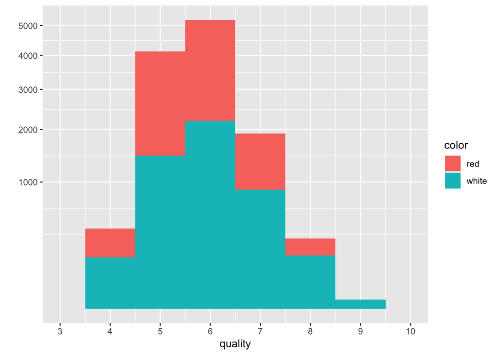

```r
library(ggplot2)
qplot(quality, data = wine, fill = color, binwidth = 1) +
    scale_x_continuous(breaks = seq(3,10,1), lim = c(3,10)) +
    scale_y_sqrt()
```

## level of alcohol

```r
summary(wine$alcohol)
```

```
##    Min. 1st Qu.  Median    Mean 3rd Qu.    Max.
##    8.00    9.50   10.30   10.49   11.30   14.90
```

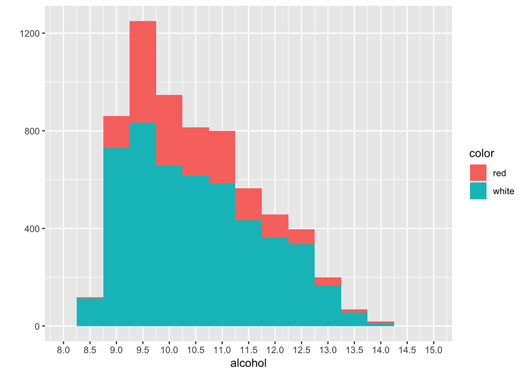

```r
qplot(alcohol, data = wine, fill = color, binwidth = 0.5) +
    scale_x_continuous(breaks = seq(8,15,0.5), lim = c(8,15))
```

## Quality of Red and White Wines

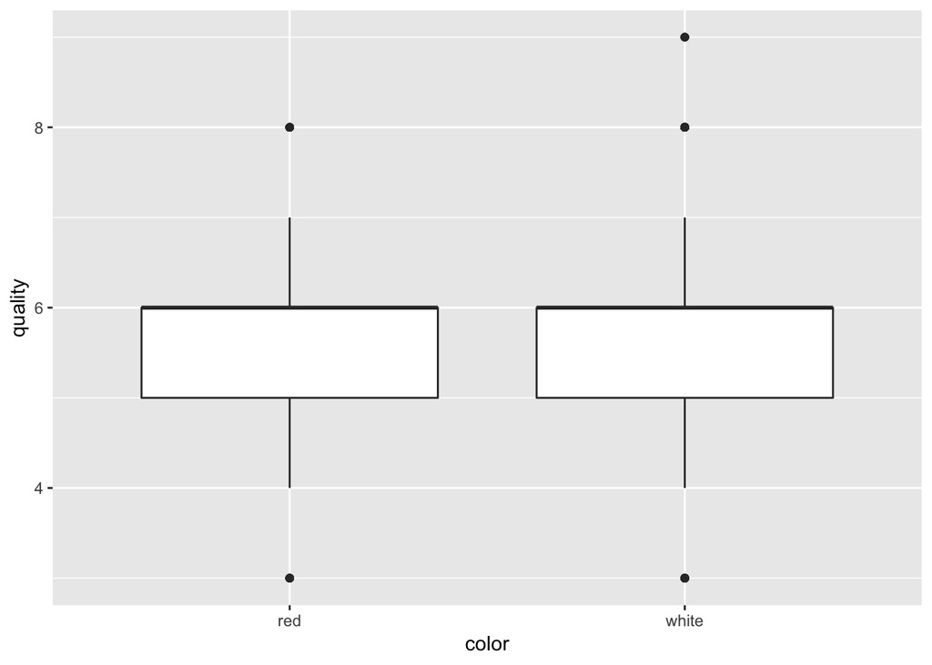

```r
qplot(x = color, y = quality, data = wine, geom = "boxplot")
```

This could be a two sample mean problem( is there any difference in quality of red wine and white wine)

## Density vs. Alcohol correlation by Color

We can either do linear regression here or simply correlation.

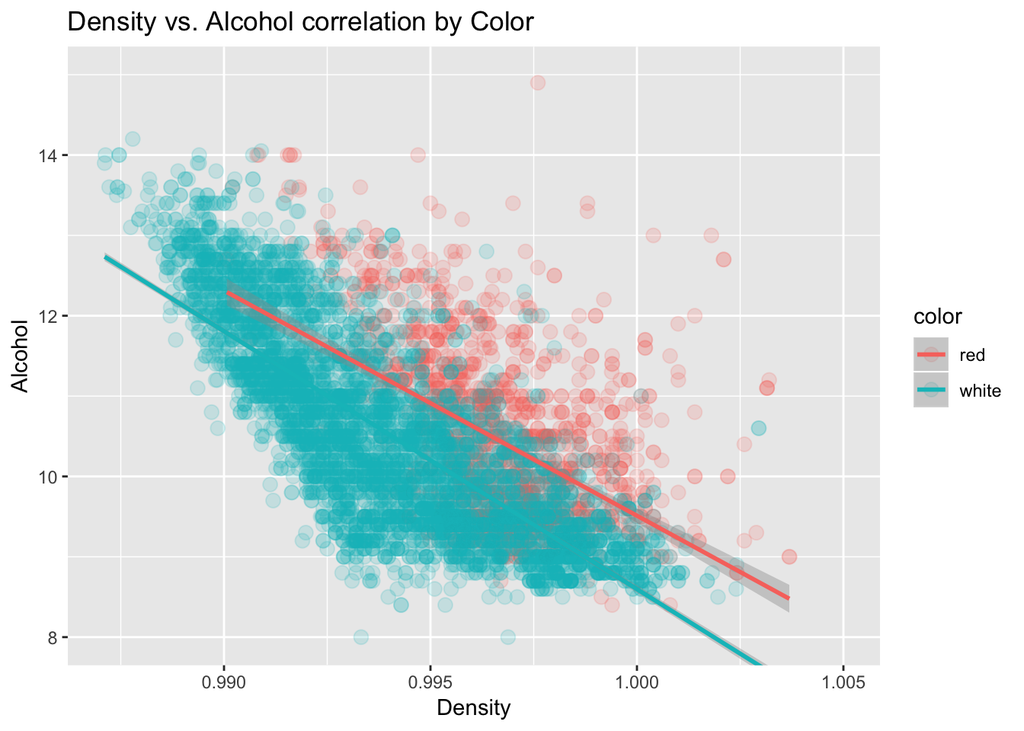

```r
ggplot(data = wine,
       aes(x = density, y = alcohol, color = color)) +
   geom_point(alpha = 1/6, position = position_jitter(h = 0), size = 3) +
   geom_smooth(method = 'lm') +
   coord_cartesian(xlim=c(min(wine$density),1.005), ylim=c(8,15)) +
   xlab('Density') +
   ylab('Alcohol') +
   ggtitle('Density vs. Alcohol correlation by Color')
```